# TIMSS 2015 in Japan. Project 2

Kostrova Anna

6/10/2021

```r
knitr::opts_chunk$set(message = FALSE)
knitr::opts_chunk$set(warning  = FALSE)
```

# Aim of the study and research question

This research project examines students’ attitudes towards mathematics and how the variables used for analysis break down into factors, and how they affect the student’s academic performance. The research question is: What metrics related to mathematics lessons influence the academic performance of Japanese students? The analysis used TIMSS 2015 data for Japan.

# Data preparation and descriptive statistics

A total of 4,745 responses were received from students from Japan. I used 29 variables to answer the research questions, each of which is listed in the table below. For further convenience in the interpretation of the results, the variables have been renamed. The main variable that will subsequently be predicted is “BSMMAT01” or “success”, which is responsible for the student’s academic performance.

For factor analysis, 24 variables were used that related to mathematics. So the first 9 variables collected data on students’ attitudes towards math lessons, how they progress and their attitude towards the teacher. The common question for all variables was: *How much do you agree with these statements about learning mathematics?*. СThe following 10 variables were responsible for the student’s attitude towards math lessons and answered the general question: *How much do you agree with these statements about your mathematics lessons?*. The last 5 questions examined the student’s general attitude towards mathematics, in particular, how easy or, conversely, difficult for him or her the subject is given. The common question was: *How much do you agree with these statements about mathematics?*.

As future control variables for the regression analysis, I used 4 additional variables: gender, parental education, and whether the student was born in Japan or another country.

```r
library(haven)
library(dplyr)
library(foreign)
library(psych)
library(polycor)
library(corrplot)
library(sjPlot)
library(summarytools)
library(lmtest)
library(car)
library(gridExtra)
library(ggplot2)
library(GPArotation)
library(polycor)
library(ggcorrplot)
library(DT)
library(gtable)
library(grid)
library(knitr)
library(kableExtra)
```

```r
data <- read.spss("~/Downloads/BSGJPNM6.sav", to.data.frame = TRUE, use.value.labels = TRUE) %>% select(BSBM17A, BSBM17B, BSBM17C, BSBM17D, BSBM17E, BSBM17F, BSBM17G, BSBM17H, BSBM17I, BSBM18A, BSBM18B, BSBM18C, BSBM18D, BSBM18E, BSBM18F, BSBM18G, BSBM18H, BSBM18I, BSBM18J, BSBM19A, BSBM19B, BSBM19C, BSBM19D, BSBM19E, BSBG01, BSBG07A, BSBG07B, BSBG10A, BSMMAT01)


data = data %>% rename( enjoy= BSBM17A, study = BSBM17B, boring = BSBM17C, intrst = BSBM17D, likemath = BSBM17E, likenumb = BSBM17F, likesolve= BSBM17G, lookfrwrd= BSBM17H, fav = BSBM17I, expect = BSBM18A, undrstnd= BSBM18B, intrst_teacher= BSBM18C, intrst_things = BSBM18D, answers= BSBM18E, explain = BSBM18F, learned = BSBM18G, help = BSBM18H, mistake = BSBM18I, listen = BSBM18J, dowell= BSBM19A, diffclt = BSBM19B, not_strength= BSBM19C, quickly= BSBM19D, nervous = BSBM19E, sex = BSBG01, mother = BSBG07A, father = BSBG07B, country = BSBG10A, success = BSMMAT01)

data$success = as.numeric(as.character(data$success))

`Name of variable` <- c("BSBG01", "BSBG07A", "BSBG07B", "BSBG10A", "BSMMAT01", "BSBM17A", "BSBM17B", "BSBM17C", "BSBM17D", "BSBM17E", "BSBM17F", "BSBM17G", "BSBM17H", "BSBM17I", "BSBM18A", "BSBM18B", "BSBM18C", "BSBM18D", "BSBM18E", "BSBM18F", "BSBM18G", "BSBM18H", "BSBM18I", "BSBM18J", "BSBM19A", "BSBM19B", "BSBM19C", "BSBM19D", "BSBM19E")

`Question` <- c("Are you a girl or a boy?",
                "What is the highest level of education completed by your mother (or stepmother or female guardian)?",
                "What is the highest level of education completed by your father (or stepfather or male guardian)?",
                "Were you born in Japan?",
                "Assesment of student's achievement",
                "How much do you agree with these statements about learning mathematics? I enjoy learning mathematics",
                "How much do you agree with these statements about learning mathematics? I wish I did not have to study mathematics",
                "How much do you agree with these statements about learning mathematics? Mathematics is boring",
                "How much do you agree with these statements about learning mathematics? I learn many interesting things in mathematics",
                "How much do you agree with these statements about learning mathematics? I like mathematics",
                "How much do you agree with these statements about learning mathematics? I like any schoolwork that involves numbers",
                "How much do you agree with these statements about learning mathematics? I like to solve mathematics problems",
                "How much do you agree with these statements about learning mathematics? I look forward to mathematics class",
                "How much do you agree with these statements about learning mathematics? Mathematics is one of my favorite subjects",
                "How much do you agree with these statements about your mathematics lessons? I know what my teacher expects me to do",
                "How much do you agree with these statements about your mathematics lessons? My teacher is easy to understand",
                "How much do you agree with these statements about your mathematics lessons? I am interested in what my teacher says",
                "How much do you agree with these statements about your mathematics lessons? My teacher gives me interesting things to do",
                "How much do you agree with these statements about your mathematics lessons? My teacher has clear answers to my questions",
                "How much do you agree with these statements about your mathematics lessons? My teacher is good at explaining mathematics",
                "How much do you agree with these statements about your mathematics lessons? My teacher lets me show what I have learned",
                "How much do you agree with these statements about your mathematics lessons? My teacher does a variety of things to help us learn",
                "How much do you agree with these statements about your mathematics lessons? My teacher tells me how to do better when I make a mistake",
                "How much do you agree with these statements about your mathematics lessons? My teacher listens to what I have to say",
                "How much do you agree with these statements about mathematics? I usually do well in mathematics",
                "How much do you agree with these statements about mathematics? Mathematics is more difficult for me than for many of my classmates",
                "How much do you agree with these statements about mathematics? Mathematics is not one of my strengths",
                "How much do you agree with these statements about mathematics? I learn things quickly in mathematics",
                "How much do you agree with these statements about mathematics? Mathematics makes me nervous")

`New name` <- c("sex" , "mother" , "father" , "country" , "success" , "enjoy", "study", "boring", "intrst", "likemath", "likenumb", "likesolve", "lookfrwrd", "fav", "expect", "undrstnd", "intrst_teacher", "intrst_things", "answers", "explain", "learned", "help", "mistake", "listen", "dowell", "diffclt", "not_strength", "quickly", "nervous")

tab <- data.frame(`Name of variable`, `Question`,`New name`)

tab %>% datatable(colnames = c('Previous name' = 2, 'New name' = 4), options = list(pageLength=5, scrollX='400px', scrollY='270px'))
```

|  | Previous name | Question | New name |
| --- | --- | --- | --- |
| 1 | BSBG01 | Are you a girl or a boy? | sex |
| 2 | BSBG07A | What is the highest level of education completed by your mother (or stepmother or female guardian)? | mother |
| 3 | BSBG07B | What is the highest level of education completed by your father (or stepfather or male guardian)? | father |
| 4 | BSBG10A | Were you born in Japan? | country |
| 5 | BSMMAT01 | Assesment of student's achievement | success |
| 6 | BSBM17A | How much do you agree with these statements about learning mathematics? I enjoy learning mathematics | enjoy |
| 7 | BSBM17B | How much do you agree with these statements about learning mathematics? I wish I did not have to study mathematics | study |
| 8 | BSBM17C | How much do you agree with these statements about learning mathematics? Mathematics is boring | boring |
| 9 | BSBM17D | How much do you agree with these statements about learning mathematics? I learn many interesting things in mathematics | intrst |
| 10 | BSBM17E | How much do you agree with these statements about learning mathematics? I like mathematics | likemath |

[output cut: 19 more lines]

It is also important to examine the presence of missing values. First, let’s look at how many in total there were missing values, or rather, what percentage they make up of the total amount of data.

```r
kable(paste0(round(((nrow(data) - nrow(na.omit(data)))/nrow(data))*100,2), "%"), col.names = "Percent of NA") %>%
  kable_styling(bootstrap_options=c("bordered", "responsive","striped"), full_width = FALSE)
```

| Percent of NA |
| --- |
| 4% |

Missing data accounts for about 4% of the total. This percentage is very small, so I decided to use the imputation method. The imputation method suggests missing data. This is most useful when the percentage of missing data is small. Before imputation, you need to understand which specific variables are NA. For this I use the summary () function.

| **Variable** | **Stats / Values** | **Freqs (% of Valid)** | **Missing** |
| --- | --- | --- | --- |
| enjoy [factor] | 1. Agree a lot 2. Agree a little 3. Disagree a little 4. Disagree a lot | 739 ( 15.6% ) 1741 ( 36.8% ) 1626 ( 34.3% ) 631 ( 13.3% ) | 8 (0.2%) |
| study [factor] | 1. Agree a lot 2. Agree a little 3. Disagree a little 4. Disagree a lot | 588 ( 12.4% ) 1191 ( 25.2% ) 1993 ( 42.1% ) 962 ( 20.3% ) | 11 (0.2%) |
| boring [factor] | 1. Agree a lot 2. Agree a little 3. Disagree a little 4. Disagree a lot | 501 ( 10.6% ) 1304 ( 27.7% ) 2185 ( 46.4% ) 717 ( 15.2% ) | 38 (0.8%) |
| intrst [factor] | 1. Agree a lot 2. Agree a little 3. Disagree a little 4. Disagree a lot | 553 ( 11.7% ) 1607 ( 34.0% ) 1997 ( 42.3% ) 567 ( 12.0% ) | 21 (0.4%) |
| likemath [factor] | 1. Agree a lot 2. Agree a little 3. Disagree a little 4. Disagree a lot | 707 ( 15.0% ) 1315 ( 27.9% ) 1732 ( 36.7% ) 961 ( 20.4% ) | 30 (0.6%) |
| likenumb [factor] | 1. Agree a lot 2. Agree a little 3. Disagree a little 4. Disagree a lot | 265 ( 5.6% ) 925 ( 19.5% ) 2571 ( 54.3% ) 975 ( 20.6% ) | 9 (0.2%) |
| likesolve [factor] | 1. Agree a lot 2. Agree a little 3. Disagree a little 4. Disagree a lot | 592 ( 12.5% ) 1402 ( 29.6% ) 1825 ( 38.6% ) 914 ( 19.3% ) | 12 (0.3%) |
| lookfrwrd [factor] | 1. Agree a lot 2. Agree a little 3. Disagree a little 4. Disagree a lot | 337 ( 7.1% ) 1107 ( 23.4% ) 2219 ( 46.9% ) 1070 ( 22.6% ) | 12 (0.3%) |
| fav [factor] | 1. Agree a lot 2. Agree a little 3. Disagree a little 4. Disagree a lot | 631 ( 13.3% ) 953 ( 20.1% ) 1798 ( 38.0% ) 1353 ( 28.6% ) | 10 (0.2%) |
| expect [factor] | 1. Agree a lot 2. Agree a little 3. Disagree a little 4. Disagree a lot | 232 ( 4.9% ) 1185 ( 25.0% ) 2386 ( 50.4% ) 931 ( 19.7% ) | 11 (0.2%) |
| undrstnd [factor] | 1. Agree a lot 2. Agree a little 3. Disagree a little 4. Disagree a lot | 937 ( 19.8% ) 2466 ( 52.1% ) 973 ( 20.6% ) 357 ( 7.5% ) | 12 (0.3%) |
| intrst_teacher [factor] | 1. Agree a lot 2. Agree a little 3. Disagree a little 4. Disagree a lot | 645 ( 13.6% ) 1793 ( 37.9% ) 1729 ( 36.6% ) 563 ( 11.9% ) | 15 (0.3%) |
| intrst_things [factor] | 1. Agree a lot 2. Agree a little 3. Disagree a little 4. Disagree a lot | 253 ( 5.4% ) 1172 ( 24.8% ) 2482 ( 52.5% ) 821 ( 17.4% ) | 17 (0.4%) |
| answers [factor] | 1. Agree a lot 2. Agree a little 3. Disagree a little 4. Disagree a lot | 1048 ( 22.2% ) 2580 ( 54.6% ) 843 ( 17.8% ) 257 ( 5.4% ) | 17 (0.4%) |
| explain [factor] | 1. Agree a lot 2. Agree a little 3. Disagree a little 4. Disagree a lot | 1149 ( 24.3% ) 2352 ( 49.7% ) 906 ( 19.2% ) 323 ( 6.8% ) | 15 (0.3%) |
| learned [factor] | 1. Agree a lot 2. Agree a little 3. Disagree a little 4. Disagree a lot | 343 ( 7.3% ) 1504 ( 31.9% ) 2161 ( 45.8% ) 712 ( 15.1% ) | 25 (0.5%) |
| help [factor] | 1. Agree a lot 2. Agree a little 3. Disagree a little 4. Disagree a lot | 1084 ( 22.9% ) 2660 ( 56.2% ) 761 ( 16.1% ) 224 ( 4.7% ) | 16 (0.3%) |
| mistake [factor] | 1. Agree a lot 2. Agree a little 3. Disagree a little 4. Disagree a lot | 1024 ( 21.6% ) 2543 ( 53.7% ) 912 ( 19.3% ) 253 ( 5.3% ) | 13 (0.3%) |
| listen [factor] | 1. Agree a lot 2. Agree a little 3. Disagree a little 4. Disagree a lot | 736 ( 15.6% ) 2356 ( 49.8% ) 1244 ( 26.3% ) 396 ( 8.4% ) | 13 (0.3%) |
| dowell [factor] | 1. Agree a lot 2. Agree a little 3. Disagree a little 4. Disagree a lot | 275 ( 5.8% ) 993 ( 21.0% ) 2274 ( 48.0% ) 1191 ( 25.2% ) | 12 (0.3%) |
| diffclt [factor] | 1. Agree a lot 2. Agree a little 3. Disagree a little 4. Disagree a lot | 754 ( 15.9% ) 1519 ( 32.1% ) 1875 ( 39.6% ) 588 ( 12.4% ) | 9 (0.2%) |
| not_strength [factor] | 1. Agree a lot 2. Agree a little 3. Disagree a little 4. Disagree a lot | 1507 ( 31.9% ) 1398 ( 29.6% ) 1217 ( 25.7% ) 606 ( 12.8% ) | 17 (0.4%) |
| quickly [factor] | 1. Agree a lot 2. Agree a little 3. Disagree a little 4. Disagree a lot | 348 ( 7.4% ) 1295 ( 27.4% ) 2422 ( 51.2% ) 662 ( 14.0% ) | 18 (0.4%) |
| nervous [factor] | 1. Agree a lot 2. Agree a little 3. Disagree a little 4. Disagree a lot | 544 ( 11.5% ) 1070 ( 22.6% ) 2092 ( 44.2% ) 1024 ( 21.6% ) | 15 (0.3%) |
| sex [factor] | 1. Girl 2. Boy | 2417 ( 51.0% ) 2325 ( 49.0% ) | 3 (0.1%) |
| mother [factor] | 1. Some Primary or Lower sec 2. Lower secondary 3. Upper secondary 4. Post-secondary, non-terti 5. Short-cycle tertiary 6. Bachelor’s or equivalent 7. Postgraduate degree 8. Don’t know | 2 ( 0.0% ) 94 ( 2.0% ) 1354 ( 28.7% ) 99 ( 2.1% ) 995 ( 21.1% ) 827 ( 17.5% ) 35 ( 0.7% ) 1315 ( 27.9% ) | 24 (0.5%) |
| father [factor] | 1. Some Primary or Lower sec 2. Lower secondary 3. Upper secondary 4. Post-secondary, non-terti 5. Short-cycle tertiary 6. Bachelor’s or equivalent 7. Postgraduate degree 8. Don’t know | 5 ( 0.1% ) 133 ( 2.8% ) 1053 ( 22.4% ) 103 ( 2.2% ) 301 ( 6.4% ) 1341 ( 28.5% ) 107 ( 2.3% ) 1668 ( 35.4% ) | 34 (0.7%) |
| country [factor] | 1. Yes 2. No | 4696 ( 99.1% ) 41 ( 0.9% ) | 8 (0.2%) |
| success [numeric] | Mean (sd) : 585.3 (88.4) min ≤ med ≤ max: 243.2 ≤ 586.8 ≤ 865.1 IQR (CV) : 117.2 (0.2) | 4743 distinct values | 0 (0.0%) |

As can be seen from the results obtained, there are missing values in all factor variables. To replace them, I’ll use the mode parameter for each variable. After outputting with summery (), you can see that there are no missing values left.

```r
Mode <- function(x) {
  ux <- unique(x)
  ux[which.max(tabulate(match(x, ux)))]
}

data =  data %>% mutate_if(is.factor, funs(replace(.,is.na(.), Mode(na.omit(.)))))

kable(paste0(round(((nrow(data) - nrow(na.omit(data)))/nrow(data))*100,2), "%"), col.names = "Percent of NA") %>%
  kable_styling(bootstrap_options=c("bordered", "responsive","striped"), full_width = FALSE)
```

| Percent of NA |
| --- |
| 0% |

## Distribution of variables connected with mathematics

Before proceeding with factor analysis, it is necessary to look at the distribution of the 24 variables related to mathematics. All of them should measure how much a person agrees with a certain statement regarding the lessons of mathematics or their relationship to mathematics. Each variable has 4 levels from “Agree on many things” to “Disagree on many things”. Thanks to the summarytools package, you can look at the distribution of responses in each variable in a convenient format.

| **Variable** | **Stats / Values** | **Freqs (% of Valid)** | **Graph** |
| --- | --- | --- | --- |
| enjoy [factor] | 1. Agree a lot 2. Agree a little 3. Disagree a little 4. Disagree a lot | 739 ( 15.6% ) 1749 ( 36.9% ) 1626 ( 34.3% ) 631 ( 13.3% ) |  |
| study [factor] | 1. Agree a lot 2. Agree a little 3. Disagree a little 4. Disagree a lot | 588 ( 12.4% ) 1191 ( 25.1% ) 2004 ( 42.2% ) 962 ( 20.3% ) |  |
| boring [factor] | 1. Agree a lot 2. Agree a little 3. Disagree a little 4. Disagree a lot | 501 ( 10.6% ) 1304 ( 27.5% ) 2223 ( 46.8% ) 717 ( 15.1% ) |  |
| intrst [factor] | 1. Agree a lot 2. Agree a little 3. Disagree a little 4. Disagree a lot | 553 ( 11.7% ) 1607 ( 33.9% ) 2018 ( 42.5% ) 567 ( 11.9% ) |  |
| likemath [factor] | 1. Agree a lot 2. Agree a little 3. Disagree a little 4. Disagree a lot | 707 ( 14.9% ) 1315 ( 27.7% ) 1762 ( 37.1% ) 961 ( 20.3% ) |  |
| likenumb [factor] | 1. Agree a lot 2. Agree a little 3. Disagree a little 4. Disagree a lot | 265 ( 5.6% ) 925 ( 19.5% ) 2580 ( 54.4% ) 975 ( 20.5% ) |  |
| likesolve [factor] | 1. Agree a lot 2. Agree a little 3. Disagree a little 4. Disagree a lot | 592 ( 12.5% ) 1402 ( 29.5% ) 1837 ( 38.7% ) 914 ( 19.3% ) |  |
| lookfrwrd [factor] | 1. Agree a lot 2. Agree a little 3. Disagree a little 4. Disagree a lot | 337 ( 7.1% ) 1107 ( 23.3% ) 2231 ( 47.0% ) 1070 ( 22.6% ) |  |
| fav [factor] | 1. Agree a lot 2. Agree a little 3. Disagree a little 4. Disagree a lot | 631 ( 13.3% ) 953 ( 20.1% ) 1808 ( 38.1% ) 1353 ( 28.5% ) |  |
| expect [factor] | 1. Agree a lot 2. Agree a little 3. Disagree a little 4. Disagree a lot | 232 ( 4.9% ) 1185 ( 25.0% ) 2397 ( 50.5% ) 931 ( 19.6% ) |  |
| undrstnd [factor] | 1. Agree a lot 2. Agree a little 3. Disagree a little 4. Disagree a lot | 937 ( 19.7% ) 2478 ( 52.2% ) 973 ( 20.5% ) 357 ( 7.5% ) |  |
| intrst_teacher [factor] | 1. Agree a lot 2. Agree a little 3. Disagree a little 4. Disagree a lot | 645 ( 13.6% ) 1808 ( 38.1% ) 1729 ( 36.4% ) 563 ( 11.9% ) |  |
| intrst_things [factor] | 1. Agree a lot 2. Agree a little 3. Disagree a little 4. Disagree a lot | 253 ( 5.3% ) 1172 ( 24.7% ) 2499 ( 52.7% ) 821 ( 17.3% ) |  |
| answers [factor] | 1. Agree a lot 2. Agree a little 3. Disagree a little 4. Disagree a lot | 1048 ( 22.1% ) 2597 ( 54.7% ) 843 ( 17.8% ) 257 ( 5.4% ) |  |
| explain [factor] | 1. Agree a lot 2. Agree a little 3. Disagree a little 4. Disagree a lot | 1149 ( 24.2% ) 2367 ( 49.9% ) 906 ( 19.1% ) 323 ( 6.8% ) |  |
| learned [factor] | 1. Agree a lot 2. Agree a little 3. Disagree a little 4. Disagree a lot | 343 ( 7.2% ) 1504 ( 31.7% ) 2186 ( 46.1% ) 712 ( 15.0% ) |  |
| help [factor] | 1. Agree a lot 2. Agree a little 3. Disagree a little 4. Disagree a lot | 1084 ( 22.8% ) 2676 ( 56.4% ) 761 ( 16.0% ) 224 ( 4.7% ) |  |
| mistake [factor] | 1. Agree a lot 2. Agree a little 3. Disagree a little 4. Disagree a lot | 1024 ( 21.6% ) 2556 ( 53.9% ) 912 ( 19.2% ) 253 ( 5.3% ) |  |
| listen [factor] | 1. Agree a lot 2. Agree a little 3. Disagree a little 4. Disagree a lot | 736 ( 15.5% ) 2369 ( 49.9% ) 1244 ( 26.2% ) 396 ( 8.3% ) |  |
| dowell [factor] | 1. Agree a lot 2. Agree a little 3. Disagree a little 4. Disagree a lot | 275 ( 5.8% ) 993 ( 20.9% ) 2286 ( 48.2% ) 1191 ( 25.1% ) |  |
| diffclt [factor] | 1. Agree a lot 2. Agree a little 3. Disagree a little 4. Disagree a lot | 754 ( 15.9% ) 1519 ( 32.0% ) 1884 ( 39.7% ) 588 ( 12.4% ) |  |
| not_strength [factor] | 1. Agree a lot 2. Agree a little 3. Disagree a little 4. Disagree a lot | 1524 ( 32.1% ) 1398 ( 29.5% ) 1217 ( 25.6% ) 606 ( 12.8% ) |  |
| quickly [factor] | 1. Agree a lot 2. Agree a little 3. Disagree a little 4. Disagree a lot | 348 ( 7.3% ) 1295 ( 27.3% ) 2440 ( 51.4% ) 662 ( 14.0% ) |  |
| nervous [factor] | 1. Agree a lot 2. Agree a little 3. Disagree a little 4. Disagree a lot | 544 ( 11.5% ) 1070 ( 22.6% ) 2107 ( 44.4% ) 1024 ( 21.6% ) |  |

**Interpretation:**

## Distribution of gender and mathematic achievement score in the sample

```r
th = theme(plot.title = element_text(size=10, hjust = 0.5, face="bold"),
           text = element_text(size=8),
        axis.ticks = element_blank(),
        panel.grid = element_blank(),
        rect = element_blank(),
        panel.grid.major.y = element_line(color = "grey92", size = 0.5))

plot1 = ggplot(data, aes(x = sex, fill = sex)) +
  geom_bar() +
  ggtitle("Gender distribution\n in the sample")+
  xlab("")+
  ylab("Number of observations")+
  th

legend = gtable_filter(ggplotGrob(plot1), "guide-box")

plot2 = ggplot(data, aes(x = sex, y = success, fill = sex, color = sex)) +
        geom_boxplot(alpha = 0.5) +
        ggtitle("Comparing mathematic achievement score\nof different Gender") +
        xlab("") +
        ylab("Mathematic achievement score") +
        th
```

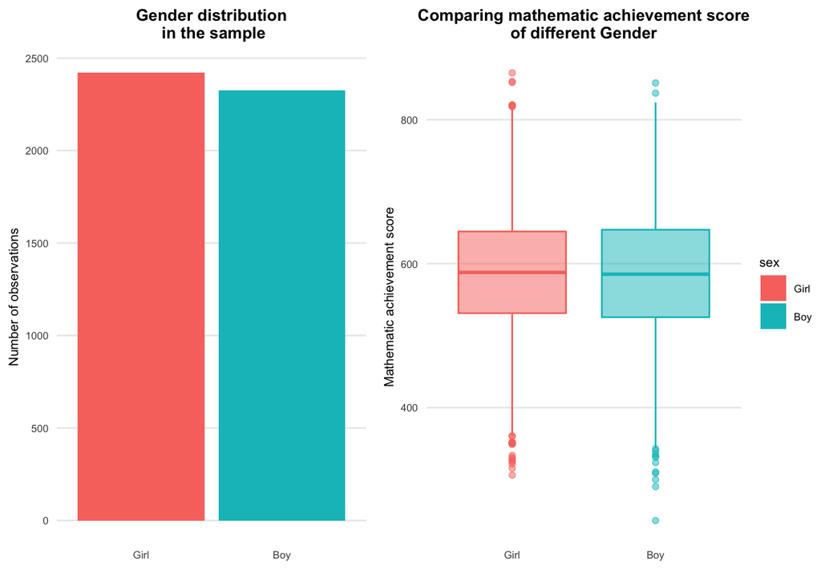

```r
#plot graphs
grid.arrange(arrangeGrob( plot1 + theme(legend.position="none"), plot2 + theme(legend.position="none"), ncol = 2), legend, widths=unit.c(unit(1, "npc") - legend$width, legend$width))
```

**Interpretation:**

- The gender of students in the data is distributed fairly evenly, which indicates the representativeness of the sample. If we compare the progress of boys and girls, we can see that there is no special dependence of academic performance on gender: the median is approximately at the same level; outlines are present in both boxplots; however, the interquartile range or “boxplot body” is wider in boys, which means that the median of the first quartile (the lower limit of the average mathematical achievement) is less, and the third (the upper limit of the average mathematical achievement) is higher than that of girls).